# Estudis d'Informàtica, Multimedia i Telecomunicacions

# Mineria de dades: PRA2 - Projecte de mineria de dades

Autor: Arnau Garcia Rodríguez

Gener 2024

# 1 Context i càrrega del joc de dades

Aquesta entrega és la continuació del projecte iniciat a la Pràctica 1, on es va preparar el joc de dades per a poder-li aplicar els mètodes supervisats i no supervisats en aquesta segona i última part de la pràctica de l’assignatura Mineria de dades.

A continuació, carreguem el joc de dades generat a partir de la primera part de la pràctica.

```r
path = 'result.csv'
studentsData <- read.csv(path, row.names=NULL)
summary(studentsData)
```

```
##        X          school              sex                 age
##  Min.   :  1   Length:649         Length:649         Min.   :15.00
##  1st Qu.:163   Class :character   Class :character   1st Qu.:16.00
##  Median :325   Mode  :character   Mode  :character   Median :17.00
##  Mean   :325                                         Mean   :16.74
##  3rd Qu.:487                                         3rd Qu.:18.00
##  Max.   :649                                         Max.   :22.00
##    address            Pstatus               Medu            Fedu
##  Length:649         Length:649         Min.   :0.000   Min.   :0.000
##  Class :character   Class :character   1st Qu.:2.000   1st Qu.:1.000
##  Mode  :character   Mode  :character   Median :2.000   Median :2.000
##                                        Mean   :2.515   Mean   :2.307
##                                        3rd Qu.:4.000   3rd Qu.:3.000
##                                        Max.   :4.000   Max.   :4.000
##     failures       schoolsup            famsup              paid
##  Min.   :0.0000   Length:649         Length:649         Length:649
##  1st Qu.:0.0000   Class :character   Class :character   Class :character
##  Median :0.0000   Mode  :character   Mode  :character   Mode  :character
##  Mean   :0.2219
##  3rd Qu.:0.0000
##  Max.   :3.0000
##   activities           higher            romantic             famrel
##  Length:649         Length:649         Length:649         Min.   :1.000
##  Class :character   Class :character   Class :character   1st Qu.:4.000
##  Mode  :character   Mode  :character   Mode  :character   Median :4.000
##                                                           Mean   :3.931
##                                                           3rd Qu.:5.000
##                                                           Max.   :5.000
##     freetime        goout            Dalc            Walc            G1
##  Min.   :1.00   Min.   :1.000   Min.   :1.000   Min.   :1.00   Min.   : 0.0
##  1st Qu.:3.00   1st Qu.:2.000   1st Qu.:1.000   1st Qu.:1.00   1st Qu.:10.0
##  Median :3.00   Median :3.000   Median :1.000   Median :2.00   Median :11.0
##  Mean   :3.18   Mean   :3.185   Mean   :1.502   Mean   :2.28   Mean   :11.4
##  3rd Qu.:4.00   3rd Qu.:4.000   3rd Qu.:2.000   3rd Qu.:3.00   3rd Qu.:13.0
##  Max.   :5.00   Max.   :5.000   Max.   :5.000   Max.   :5.00   Max.   :19.0
##        G2              G3        absencesIntervals       PC1
##  Min.   : 0.00   Min.   : 0.00   Length:649         Min.   :-6.6565
##  1st Qu.:10.00   1st Qu.:10.00   Class :character   1st Qu.:-1.2437
##  Median :11.00   Median :12.00   Mode  :character   Median : 0.2128
##  Mean   :11.57   Mean   :11.91                      Mean   : 0.0000
##  3rd Qu.:13.00   3rd Qu.:14.00                      3rd Qu.: 1.3151
##  Max.   :19.00   Max.   :19.00                      Max.   : 4.3089
##       PC2               PC3               PC4                PC5
##  Min.   :-5.0213   Min.   :-4.2289   Min.   :-4.06579   Min.   :-4.33257
##  1st Qu.:-0.8312   1st Qu.:-0.8195   1st Qu.:-0.66879   1st Qu.:-0.67215
##  Median : 0.1203   Median : 0.0597   Median : 0.08278   Median : 0.06063
##  Mean   : 0.0000   Mean   : 0.0000   Mean   : 0.00000   Mean   : 0.00000
##  3rd Qu.: 1.0063   3rd Qu.: 0.8142   3rd Qu.: 0.80752   3rd Qu.: 0.68832
##  Max.   : 3.1303   Max.   : 3.8515   Max.   : 3.06151   Max.   : 2.91078
```

Podem observar els components principals afegits al joc de dades, a part de tota la preparació i neteja que vam dur a terme.

# 2 Anàlisi de dades

Primer, analitzarem les dades mitjançant models no supervisats.

## 2.1 Models no supervisats

### 2.1.1 Distància

Utilitzarem el mètode *k-means*, que és un mètode d’agrupament basant-se en la similitud de les observacions, la qual es mesura com la distància entre els punts de dades.

Prescindirem de l’atribut G3 i ens basarem en les dimensions numèriques G1, G2 i edat per a predir la nota de l’estudiant. No tenim gaires variables numèriques contínues, per la qual cosa hem utilitzat les úniques que tenim disponibles. Discretitzarem G3 per a poder fer la comparació posteriorment amb el resultat de kmeans.

```r
library(arules)

studentsData['G3d'] <- discretize(studentsData$G3, method="interval", categories = 4, labels = c('D','C','B','A'), ordered=FALSE, onlycuts=FALSE)
summary(studentsData)
```

```
##        X          school              sex                 age
##  Min.   :  1   Length:649         Length:649         Min.   :15.00
##  1st Qu.:163   Class :character   Class :character   1st Qu.:16.00
##  Median :325   Mode  :character   Mode  :character   Median :17.00
##  Mean   :325                                         Mean   :16.74
##  3rd Qu.:487                                         3rd Qu.:18.00
##  Max.   :649                                         Max.   :22.00
##    address            Pstatus               Medu            Fedu
##  Length:649         Length:649         Min.   :0.000   Min.   :0.000
##  Class :character   Class :character   1st Qu.:2.000   1st Qu.:1.000
##  Mode  :character   Mode  :character   Median :2.000   Median :2.000
##                                        Mean   :2.515   Mean   :2.307
##                                        3rd Qu.:4.000   3rd Qu.:3.000
##                                        Max.   :4.000   Max.   :4.000
##     failures       schoolsup            famsup              paid
##  Min.   :0.0000   Length:649         Length:649         Length:649
##  1st Qu.:0.0000   Class :character   Class :character   Class :character
##  Median :0.0000   Mode  :character   Mode  :character   Mode  :character
##  Mean   :0.2219
##  3rd Qu.:0.0000
##  Max.   :3.0000
##   activities           higher            romantic             famrel
##  Length:649         Length:649         Length:649         Min.   :1.000
##  Class :character   Class :character   Class :character   1st Qu.:4.000
##  Mode  :character   Mode  :character   Mode  :character   Median :4.000
##                                                           Mean   :3.931
##                                                           3rd Qu.:5.000
##                                                           Max.   :5.000
##     freetime        goout            Dalc            Walc            G1
##  Min.   :1.00   Min.   :1.000   Min.   :1.000   Min.   :1.00   Min.   : 0.0
##  1st Qu.:3.00   1st Qu.:2.000   1st Qu.:1.000   1st Qu.:1.00   1st Qu.:10.0
##  Median :3.00   Median :3.000   Median :1.000   Median :2.00   Median :11.0
##  Mean   :3.18   Mean   :3.185   Mean   :1.502   Mean   :2.28   Mean   :11.4
##  3rd Qu.:4.00   3rd Qu.:4.000   3rd Qu.:2.000   3rd Qu.:3.00   3rd Qu.:13.0
##  Max.   :5.00   Max.   :5.000   Max.   :5.000   Max.   :5.00   Max.   :19.0
##        G2              G3        absencesIntervals       PC1
##  Min.   : 0.00   Min.   : 0.00   Length:649         Min.   :-6.6565
##  1st Qu.:10.00   1st Qu.:10.00   Class :character   1st Qu.:-1.2437
##  Median :11.00   Median :12.00   Mode  :character   Median : 0.2128
##  Mean   :11.57   Mean   :11.91                      Mean   : 0.0000
##  3rd Qu.:13.00   3rd Qu.:14.00                      3rd Qu.: 1.3151
##  Max.   :19.00   Max.   :19.00                      Max.   : 4.3089
##       PC2               PC3               PC4                PC5
##  Min.   :-5.0213   Min.   :-4.2289   Min.   :-4.06579   Min.   :-4.33257
##  1st Qu.:-0.8312   1st Qu.:-0.8195   1st Qu.:-0.66879   1st Qu.:-0.67215
##  Median : 0.1203   Median : 0.0597   Median : 0.08278   Median : 0.06063
##  Mean   : 0.0000   Mean   : 0.0000   Mean   : 0.00000   Mean   : 0.00000
##  3rd Qu.: 1.0063   3rd Qu.: 0.8142   3rd Qu.: 0.80752   3rd Qu.: 0.68832
##  Max.   : 3.1303   Max.   : 3.8515   Max.   : 3.06151   Max.   : 2.91078
##  G3d
##  D: 16
##  C: 84
##  B:418
##  A:131
##
##
```

Primer, importem la llibreria *cluster*

```r
if (!require('cluster')) install.packages('cluster')
library(cluster)
```

Seguidament, ens quedem amb les variables numèriques:

```r
x <- na.omit(studentsData[, c(4,21,22)])

summary(x)
```

```
##       age              G1             G2
##  Min.   :15.00   Min.   : 0.0   Min.   : 0.00
##  1st Qu.:16.00   1st Qu.:10.0   1st Qu.:10.00
##  Median :17.00   Median :11.0   Median :11.00
##  Mean   :16.74   Mean   :11.4   Mean   :11.57
##  3rd Qu.:18.00   3rd Qu.:13.0   3rd Qu.:13.00
##  Max.   :22.00   Max.   :19.0   Max.   :19.00
```

Com no sabem el nombre idoni de clústers, provem amb diversos valors. Es pot observar una gràfica que conté informació sobre cadascun dels models resultants de k-means, com la suma dels quadrats de les distàncies dels punts de cadascun dels clústers respecte el centre (withinss). Seleccionarem el valor que es trobi al colze de la corba, on comença a estabilitzar-se i per més clústers que afegeixis la densitat de punts no varia de forma significativa.

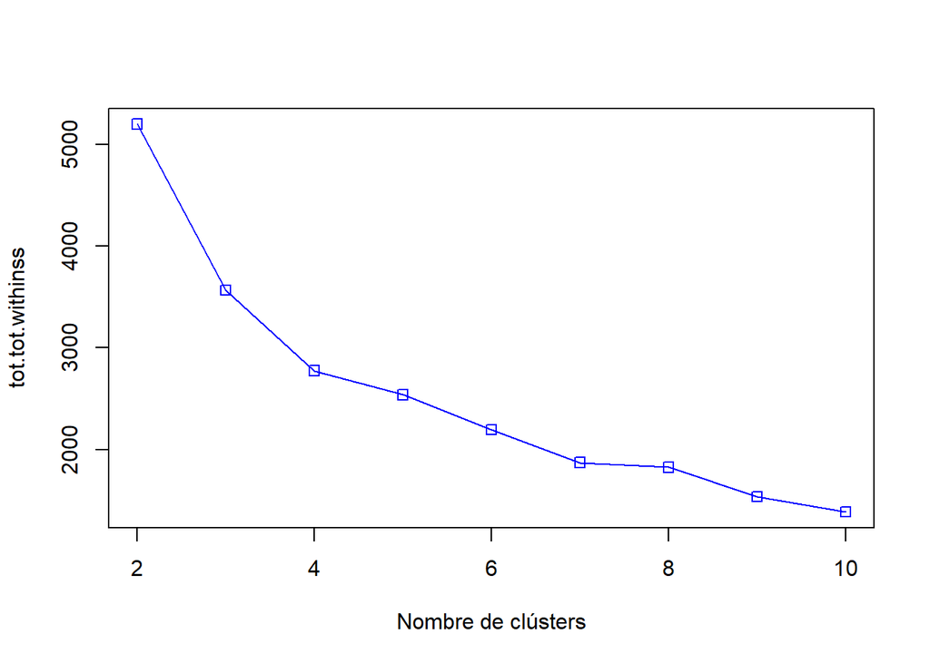

```r
resultados <- rep(0, 10)
for (i in c(2,3,4,5,6,7,8,9,10))
{
  fit           <- kmeans(x, i)
  resultados[i] <- fit$tot.withinss
}
plot(2:10,resultados[2:10],type="o",col="blue",pch=0,xlab="Nombre de clústers",ylab="tot.tot.withinss")
```

Després de veure el gràfic, decidim que el valor òptim de clústers (k) és 4.

Per a corroborar aquest resultat, existeixen llibreries d’R que ens poden ajudar. Podem utilitzar el mètode *kmeansruns* del paquet **fpc** que seleccionarà la que millor resultat obtingui d’acord amb els criteris de la silueta mitjana (asw) i *Calinski-Harabasz* (“ch”).

```r
if (!require('fpc')) install.packages('fpc'); library('fpc')
fit_ch  <- kmeansruns(x, krange = 1:10, criterion = "ch")
fit_asw <- kmeansruns(x, krange = 1:10, criterion = "asw")
```

Podem observar el valor amb el qual s’ha obtingut el millor resultat fent servir tots dos criteris.

```r
fit_ch$bestk
```

```
## [1] 2
```

```r
fit_asw$bestk
```

```
## [1] 2
```

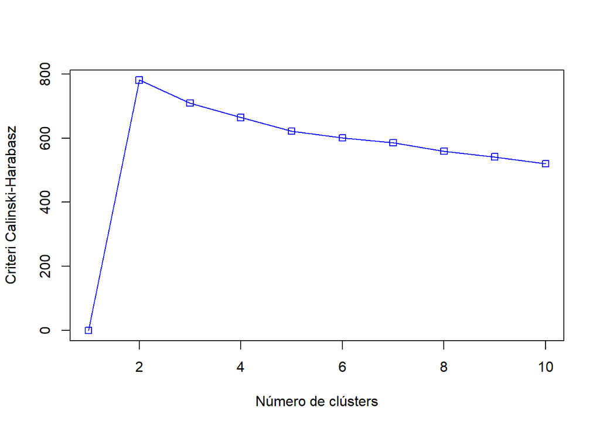

```r
plot(1:10,fit_ch$crit,type="o",col="blue",pch=0,xlab="Número de clústers",ylab="Criteri Calinski-Harabasz")
```

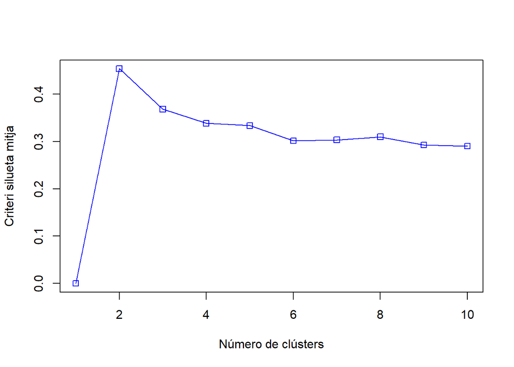

```r
plot(1:10,fit_asw$crit,type="o",col="blue",pch=0,xlab="Número de clústers",ylab="Criteri silueta mitja")
```

Tot i que indica que el millor k és 2, farem servir 4 ja que són els valors que pot prende G3d (G3 discretitzat).

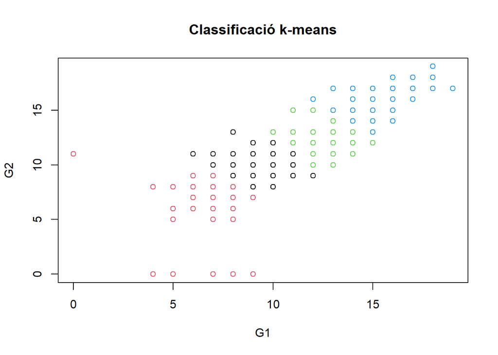

```r
set.seed(666)
stu3clusters <- kmeans(x, 4)
plot(x[c(2,3)], col=stu3clusters$cluster, main="Classificació k-means")
```

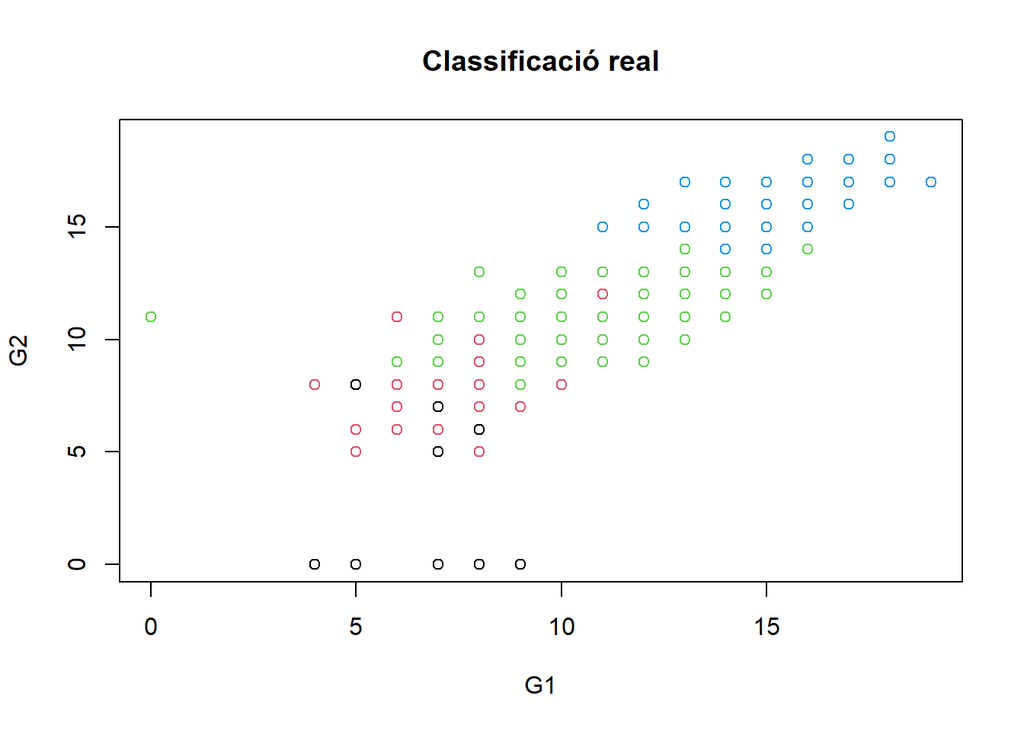

```r
plot(studentsData[c(21,22)], col=as.factor(studentsData$G3d), main="Classificació real")
```

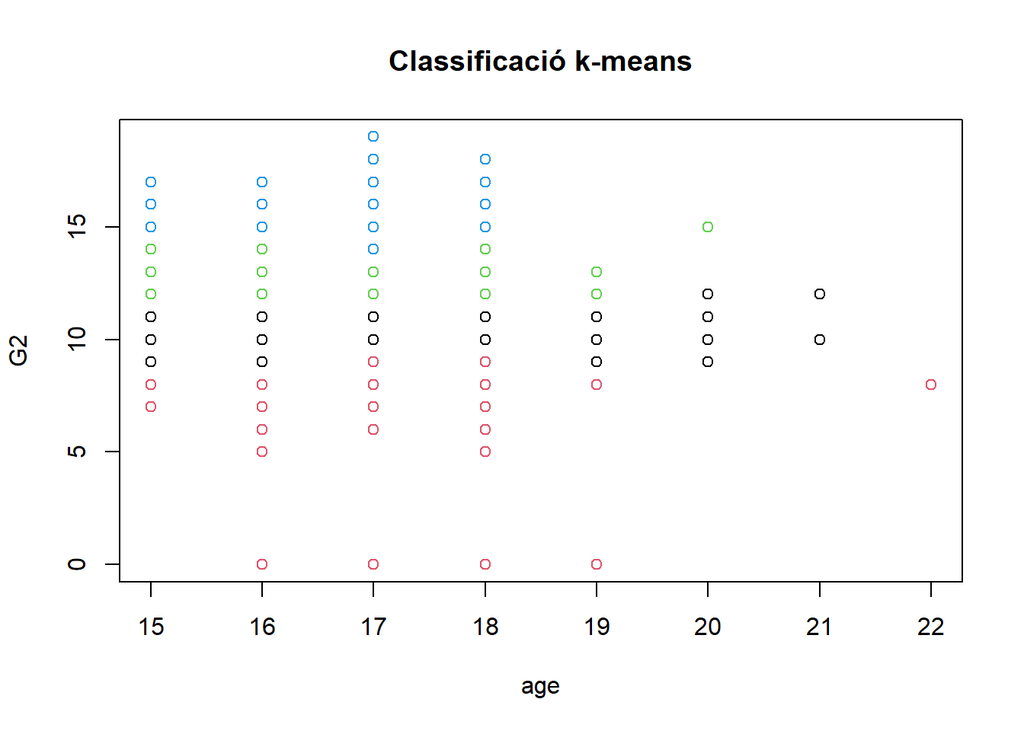

```r
plot(x[c(1,3)], col=stu3clusters$cluster, main="Classificació k-means")
```

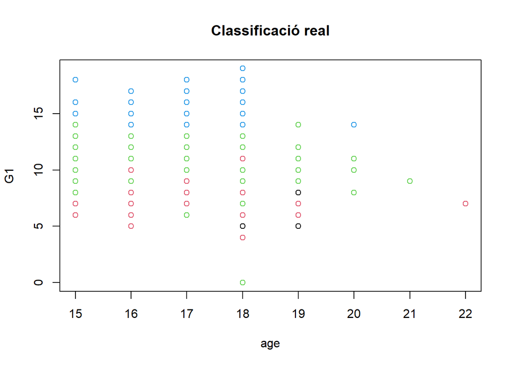

```r
plot(studentsData[c(4,21)], col=as.factor(studentsData$G3d), main="Classificació real")
```

Després de veure els gràfics anteriors, podem concloure que Classifica correctament les notes més altes, però no acaba d’encertar a la resta d’observacions.

El model anterior s’ha generat usant la mètrica de distància **Euclidiana**, que és la que utilitza el mètode *kmeans* de forma predeterminada. A continuació, generarem de nou el model utilitzant la mesura de distància **Manhattan** (algoritme **Lloyd**) mitjançant el paràmetre *algorithm*.

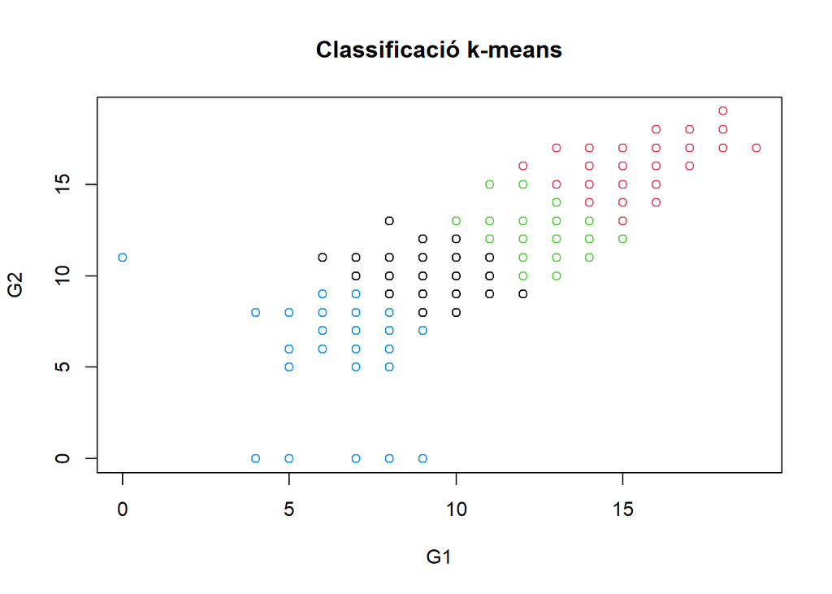

```r
stu3clusters <- kmeans(x, 4, algorithm = "Lloyd")
plot(x[c(2,3)], col=stu3clusters$cluster, main="Classificació k-means")
```

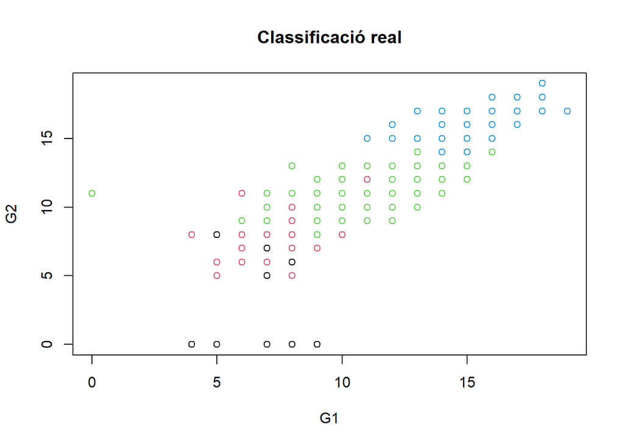

```r
plot(studentsData[c(21,22)], col=as.factor(studentsData$G3d), main="Classificació real")
```

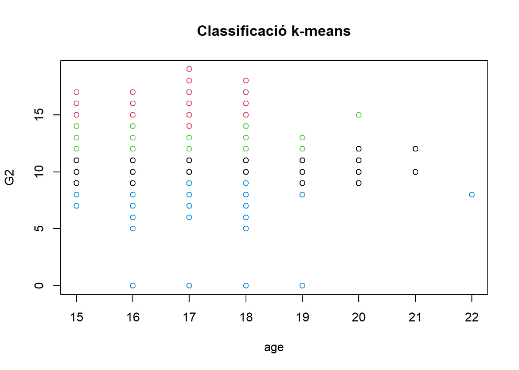

```r
plot(x[c(1,3)], col=stu3clusters$cluster, main="Classificació k-means")
```

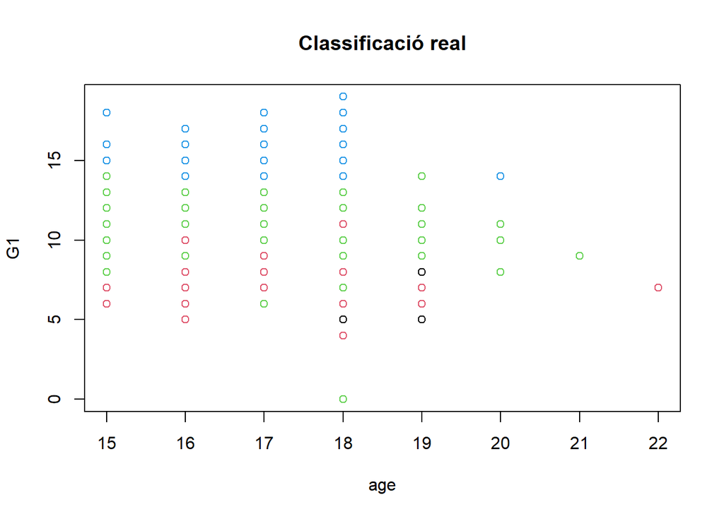

```r
plot(studentsData[c(4,21)], col=as.factor(studentsData$G3d), main="Classificació real")
```

### 2.1.2 Densitat

#### 2.1.2.1 OPTICS

**OPTICS** (*Ordering points to identify cluster structure*) generalitza DBSCAN i soluciona l’inconvenient dels paràmetres inicials. A la pràctica, aquest algoritme no genera una proposta de clústers a partir d’un joc de dades, sinó que **ordena** els punts en funció de la seva **distància d’associabilitat**. Per això, el gràfic més interessant i que millor pot il·lustrar aquest algorisme és el *reachability plot* o gràfic d’associabilitat.

Modificant els paràmetres es pot calibrar la distància d’associabilitat límit del que volem considerar un clúster.

Per tant, el primer que farem serà ordenar els punts.

```r
if (!require('dbscan')) install.packages('dbscan'); library('dbscan')

### Executem l'algoritme OPTICS deixant el paràmetre eps amb el seu valor per defecte i fixant el criteri de veïnatge en 10
res <- optics(x, minPts = 2)
res
```

```
## OPTICS ordering/clustering for 649 objects.
## Parameters: minPts = 2, eps = 5.91607978309962, eps_cl = NA, xi = NA
## Available fields: order, reachdist, coredist, predecessor, minPts, eps,
##                   eps_cl, xi
```

```r
### Obtenim la ordenació de les observacions o punts
res$order
```

```
##   [1]   1 570 640 583 633 492 591 285 283 257 644 488 641 638 513 630 625 587
##  [19] 306 179 175  19 636 579 546 442 220 602 240 589 448 623 609 628 605 580
##  [37] 577 243 626 614 372 354 325 324 302 254 232 649 632 599 576 389 309 303
##  [55] 648 532 432 645 406 629 613 585 555 498 458 439 299 242 207 190 610 384
##  [73] 295 143 647 603 399 364 361 320 305 294 608 554 508 506 374 326 308 274
##  [91] 272 194 593 403 383 368 356 293 224 615 367 332 330 318 287 269 236 234
## [109] 601 393 347 246 233 203 622 334 327 262 247 218 211 168 600 594 592 331
## [127] 329 590 531 588 627 586 180 584 582 574 558 643 571 566 173 147  62  24
## [145] 562 390 386 281 238 132 578 561 509 275 141 560 396 359 355 289 620 557
## [163] 540 487 484 453 445 252 181 165 553 481 581 572 552 527 273 634 419 410
## [181] 378 343 612 394 377 316 617 402 391 556 457 202 108  94  18 551 223 124
## [199] 100  99  93  56  23 563   5 549 486 380 278 260 235 133 548 543 452 431
## [217] 430 424 212 155  45  26 547 322 639 365 341 290 217 213 210 545 229 206
## [235] 119 544 529 494 480 263 204  79 542 512 265 231 192 187 565 541   2 539
## [253] 530 465 221 112  75  41 538 476 443 103  21  13   3 537 463 434 148 140
```

[output cut: 22 more lines]

A partir d’aquesta ordenació, podem generar l’esmentat gràfic d’associativitat. En aquest, podem observar les distàncies d’associativitat de cadascun dels punts. Les valls representen els punts més interiors dels clústers i els cims són els valors *outliners* o que es troben en zones poc denses entre clústers. Cal destacar que com més ample és la vall, més dens és el clúster, perquè més observacions es troben a prop d’aquests.

També afegim un gràfic per veure les traces de les distàncies entre punts.

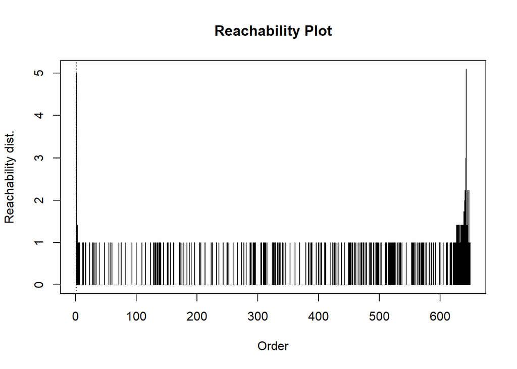

```r
### Gràfic d'accessibilitat
plot(res)
```

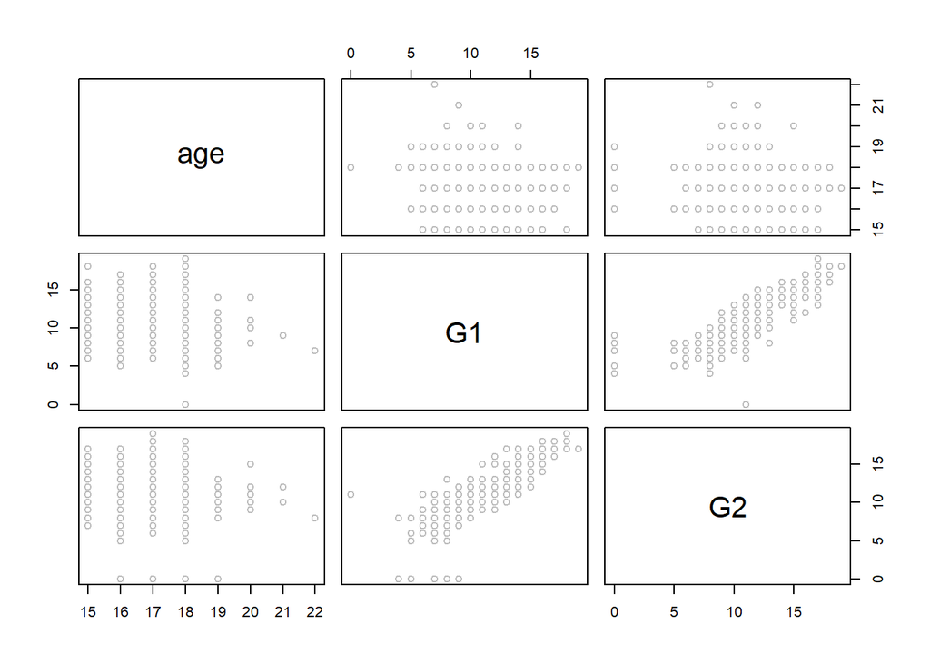

```r
### Dibuixem les traces que relacionen punts
plot(x, col = "grey")
polygon(x[res$order,])
```

## 2.2 Models supervisats

### 2.2.1 Arbre de decisió

Per a dur a terme mineria de dades mitjançant arbres de decisió, necessitem dividir el conjunt de dades entre dades **d’entrenament** i de **prova**. Les proporcions seran 2/3 i 1/3 del conjunt de dades originals, respectivament.

El camp pel qual classificarem serà *G3d* (30). Les variables per a dur a terme la predicció seran:

- Failures (9)
- G1 (21)
- G2 (22)

```r
set.seed(666)
y <- studentsData[,30]
X <- studentsData[, c(9,21,22)]
```

```r
split_prop <- 3
indexes = sample(1:nrow(studentsData), size=floor(((split_prop-1)/split_prop)*nrow(studentsData)))
trainX<-X[indexes,]
trainy<-y[indexes]
testX<-X[-indexes,]
testy<-y[-indexes]
```

```r
summary(trainX);
```

```
##     failures            G1              G2
##  Min.   :0.0000   Min.   : 0.00   Min.   : 0.00
##  1st Qu.:0.0000   1st Qu.:10.00   1st Qu.:10.00
##  Median :0.0000   Median :11.00   Median :11.50
##  Mean   :0.1921   Mean   :11.42   Mean   :11.65
##  3rd Qu.:0.0000   3rd Qu.:13.00   3rd Qu.:13.00
##  Max.   :3.0000   Max.   :19.00   Max.   :19.00
```

```r
summary(trainy)
```

```
##   D   C   B   A
##  10  49 289  84
```

```r
summary(testX)
```

```
##     failures            G1              G2
##  Min.   :0.0000   Min.   : 5.00   Min.   : 0.00
##  1st Qu.:0.0000   1st Qu.: 9.00   1st Qu.: 9.00
##  Median :0.0000   Median :11.00   Median :11.00
##  Mean   :0.2811   Mean   :11.35   Mean   :11.41
##  3rd Qu.:0.0000   3rd Qu.:13.00   3rd Qu.:13.00
##  Max.   :3.0000   Max.   :18.00   Max.   :18.00
```

```r
summary(testy)
```

```
##   D   C   B   A
##   6  35 129  47
```

La proporció dels 4 conjunts de dades és molt semblant, per tant, no haurien de poder esbiaixar les conclusions.

Primer crearem l’arbre de decisió a partir de les dades d’entrenament (trainX i trainy).

```r
if(!require(C50)){
    install.packages('C50', repos='http://cran.us.r-project.org')
    library(C50)
}
if(!require(grid)){
    install.packages('grid', repos='http://cran.us.r-project.org')
    library(grid)
}
if(!require(gridExtra)){
    install.packages('gridExtra', repos='http://cran.us.r-project.org')
    library(gridExtra)
}
trainy = as.factor(trainy)
model <- C50::C5.0(trainX, trainy,rules=TRUE )
summary(model)
```

```
##
## Call:
## C5.0.default(x = trainX, y = trainy, rules = TRUE)
##
##
## C5.0 [Release 2.07 GPL Edition]      Sun Jan 14 13:52:11 2024
## -------------------------------
##
## Class specified by attribute `outcome'
##
## Read 432 cases (4 attributes) from undefined.data
##
## Rules:
##
## Rule 1: (4, lift 36.0)
##  G2 <= 0
##  ->  class D  [0.833]
##
## Rule 2: (38/7, lift 7.1)
##  G2 > 0
##  G2 <= 8
##  ->  class C  [0.800]
##
## Rule 3: (288/21, lift 1.4)
##  G2 > 8
##  G2 <= 13
##  ->  class B  [0.924]
##
## Rule 4: (102/20, lift 4.1)
##  G2 > 13
##  ->  class A  [0.798]
##
## Default class: B
##
##
## Evaluation on training data (432 cases):
##
##          Rules
##    ----------------
##      No      Errors
##
##       4   48(11.1%)   <<
##
##
##     (a)   (b)   (c)   (d)    <-classified as
##    ----  ----  ----  ----
##       4     5     1          (a): class D
##            31    18          (b): class C
##             2   267    20    (c): class B
##                   2    82    (d): class A
##
##
##  Attribute usage:
##
##  100.00% G2
##
##
## Time: 0.0 secs
```

A continuació, mostrem l’arbre resultant.

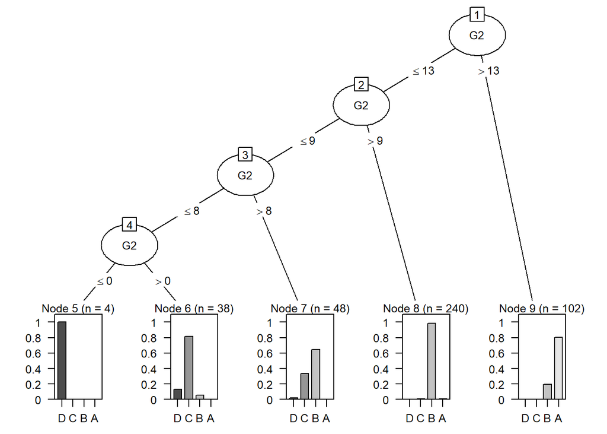

```r
model <- C50::C5.0(trainX, trainy)
plot(model,gp = gpar(fontsize = 9.5))
```

Veiem un arbre amb una profunditat de 5 nivells.

- Node 5: 4 observacions de les quals el 100% són un D.
- Node 6: 38 observacions de les quals el 80% són una C.
- Node 7: 48 observacions de les quals el 60% són un B.
- Node 8: 240 observacions de les quals gairebé el 100% són un B.
- Node 9: 102 observacions de les quals el 80% són un A.

Comprovarem la qualitat del model predient la classe G3d amb les dades de prova que hem inicialitzat anteriorment.

```r
predicted_model <- predict( model, testX, type="class" )
print(sprintf("La precisió de l'arbre és: %.4f%%",100*sum(predicted_model == testy) / length(predicted_model)))
```

```
## [1] "La precisió de l'arbre és: 86.6359%"
```

Ara mostrarem la matriu de confusió. Aquesta permet identificar els tipus d’errors comesos.

```r
mat_conf<-table(testy,Predicted=predicted_model)
mat_conf
```

```
##      Predicted
## testy   D   C   B   A
##     D   3   2   1   0
##     C   0  21  14   0
##     B   0   5 119   5
##     A   0   0   2  45
```

### 2.2.2 Models de regressió

En aquest apartat predirem la variable **G3** mitjançant anàlisi regressiva. Per tant, el primer que farem serà crear model de regressió lineal mitjançant la funció **lm** i les variables independents seran les mateixes que a l’arbre de decisió (failures, G1, G2). També, comprovarem que totes les variables involucrades siguin numèriques.

```r
str(studentsData[, c("G3", "failures", "G1", "G2")])
```

```
## 'data.frame':    649 obs. of  4 variables:
##  $ G3      : int  11 11 12 14 13 13 13 13 17 13 ...
##  $ failures: int  0 0 0 0 0 0 0 0 0 0 ...
##  $ G1      : int  0 9 12 14 11 12 13 10 15 12 ...
##  $ G2      : int  11 11 13 14 13 12 12 13 16 12 ...
```

```r
model <- lm(G3 ~ failures + G1 + G2, data = studentsData)

summary(model)
```

```
##
## Call:
## lm(formula = G3 ~ failures + G1 + G2, data = studentsData)
##
## Residuals:
##     Min      1Q  Median      3Q     Max
## -9.1930 -0.4463 -0.0835  0.6101  5.6370
##
## Coefficients:
##             Estimate Std. Error t value Pr(>|t|)
## (Intercept)  0.08514    0.24117   0.353 0.724197
## failures    -0.21086    0.09085  -2.321 0.020602 *
## G1           0.13976    0.03610   3.872 0.000119 ***
## G2           0.88803    0.03403  26.093  < 2e-16 ***
## ---
## Signif. codes:  0 '***' 0.001 '**' 0.01 '*' 0.05 '.' 0.1 ' ' 1
##
## Residual standard error: 1.258 on 645 degrees of freedom
## Multiple R-squared:  0.849,  Adjusted R-squared:  0.8483
## F-statistic:  1209 on 3 and 645 DF,  p-value: < 2.2e-16
```

Algunes interpretacions:

- El coeficient negatiu per a failures indica que a mesura que augmenta el nombre de fallides, la variable dependent (G3) disminueix.
- Els coeficients positius per a G1 i G2 suggereixen que valors més alts de G1 i G2 estan associats amb valors més alts de G3.
- El model explica aproximadament el 84,9% de la variància en la variable dependent G3.
- L’estadística F és molt significativa (p-value < 2.2e-16), indicant que el model global és significatiu.

En general, el model sembla ser una bona ajustada, i els predictors (failures, G1, G2) són importants per explicar la variabilitat en la variable dependent G3.

# 3 Limitacions

Ens hem trobat diverses limitacions i dificultats a l’hora de generar alguns dels models, a causa de la fase de tractament i neteja de les dades (primera part d’aquest projecte).

Durant la creació del model no supervisat k-means, ens hem trobat que no teníem gaires variables numèriques contínues pel que no he tingut cap flexibilitat a l’hora d’escollir-les. A més, he necessitat afegir la variable G3 discretitzada per a poder tenir una variable dependent etiquetada, cosa que hauria d’haver fet a la fase de tractament de les dades.

A l’arbre de decisió, m’he adonat que no tenia gaires variables correlacionades significativament amb G3. Amb qualsevol de les variables que tenia disponibles, l’arbre sempre acabava tenint regles basades en G1 i G2, que clarament són les més correlacionades amb G3.

# 4 Riscos

Cada model estadístic dels que hem utilitzat té els seus propis riscos i limitacions. A continuació, proporcionarem una breu descripció dels riscos i limitacions comunes de cadascun dels models.

**K-means** és molt sensible a l’elecció inicial dels centroides, per la qual cosa a cada execució es poden arribar a obtenir resultats diferents. També és molt dependent a l’elecció de k. En el nostre cas, ho hem tingut fàcil perquè sabíem amb anterioritat el nombre de clústers que volíem classificar. En últim lloc, aquest algoritme assumeix que els clústers tenen una forma geomètrica esfèrica, característica que pot no ser apropiada per al conjunt de dades que estem analitzant.

**Els arbres de decisió** poden patir *overfitting*, és a dir, s’adapten massa a les dades d’entrenament i no generalitzen bé, de forma que no proporciona bones prediccions amb noves dades. En el nostre cas no ha succeït, ja que quan hem provat amb les dades de test hem assolit una precisió del 86,6359%. A més, els arbres de decisió poden resultar inestables, pel fet que petites variacions a les dades d’entrenament poden resultar en arbres de decisió significativament diferents.

Els models de **regressió lineal** assumeixen linealitat, homoscedasticitat i normalitat dels residus. Si aquests requisits no es compleixen, els resultats podrien estar esbiaixats o podrien resultar poc fiables. Els *outliners* poden tenir un gran impacte sobre el model, sobretot si tenen una influència desproporcionada a l’estimació dels paràmetres. De la mateixa forma que als arbres de decisió, existeix el perill d’overfitting* si s’utilitzen massa variables predictores.

Per tant, és crucial tenir en compte tots aquests riscos i consideracions abans de decidir quin model emprar en un context determinat. L’elecció d’un model no és una decisió trivial i requereix una comprensió profunda de les característiques específiques de les dades i el problema que volem abordar.